Borrador

# Análisis completo · Sesión 4

Regresión simple I: del problema al modelo — precio en función de recámaras

Autor/a

Consultora de Análisis (equipo docente)

Fecha de publicación

15 de abril, 2026

> **Propósito de este documento.** Es el análisis completo que subyace la presentación de la Sesión 4. Se ejecuta de principio a fin con datos reales y permite: (a) validar que no haya placeholders en las slides, (b) obtener los números exactos para la narrativa profesional a Patricia, (c) servir como modelo de respuesta que los alumnos pueden consultar después de la clase.

> **No se publica en el sitio.** Vive en `analisis/` que está excluida del render.

## 1. Setup

```r
library(dplyr)
library(readr)
library(ggplot2)
library(scales)
library(knitr)

# Pipeline alineado con las slides públicas: csv crudo de Inside Airbnb,
# nombres originales, limpieza mínima.
listings <- read_csv("../datos/listings_cdmx_raw.csv.gz",
                     show_col_types = FALSE)

n_crudo <- nrow(listings)

listings <- listings |>
  mutate(price = parse_number(price)) |>
  filter(!is.na(price))

n_limpio <- nrow(listings)

# Fecha del snapshot
meses_es <- c("enero", "febrero", "marzo", "abril", "mayo", "junio",
              "julio", "agosto", "septiembre", "octubre", "noviembre",
              "diciembre")
fecha_corte_date <- max(listings$last_scraped, na.rm = TRUE)
fecha_corte_iso  <- format(fecha_corte_date, "%Y-%m-%d")
fecha_corte_txt  <- paste0(
  as.integer(format(fecha_corte_date, "%d")), " de ",
  meses_es[as.integer(format(fecha_corte_date, "%m"))], " de ",
  format(fecha_corte_date, "%Y")
)

cat("Listings en el crudo : ", format(n_crudo,  big.mark = ","), "\n",
    "Listings tras limpiar: ", format(n_limpio, big.mark = ","),
    " (drop ", format(n_crudo - n_limpio, big.mark = ","), ")\n",
    "Fecha de corte       : ", fecha_corte_iso, "\n",
    sep = "")
```

```
Listings en el crudo : 27,051
Listings tras limpiar: 23,567 (drop 3,484)
Fecha de corte       : 2025-09-28
```

```r
# Paleta del curso
colores <- list(
  primary = "#2C3E50",
  accent  = "#18BC9C",
  info    = "#3498DB",
  warn    = "#F39C12",
  danger  = "#E74C3C",
  light   = "#ECF0F1"
)

# Tema de ggplot reusable
theme_curso <- function() {
  theme_minimal(base_size = 12) +
    theme(
      plot.title = element_text(face = "bold", color = colores$primary),
      plot.subtitle = element_text(color = "#7F8C8D"),
      axis.title = element_text(color = colores$primary),
      panel.grid.minor = element_blank(),
      panel.grid.major = element_line(color = colores$light)
    )
}
```

## 2. Subset: Roma Norte, propiedad completa

El mercado de Patricia: propiedades completas (`Entire home/apt`) en Roma Norte, con información de recámaras disponible.

```r
roma <- listings |>
  filter(host_neighbourhood == "Roma Norte",
         room_type == "Entire home/apt",
         !is.na(bedrooms))

cat("Listings en el subset (Roma Norte, Entire, bedrooms no-NA):",
    nrow(roma), "\n")
```

```
Listings en el subset (Roma Norte, Entire, bedrooms no-NA): 981
```

## 3. Exploración: precio vs recámaras

### 3.1 Distribución de recámaras

```r
roma |>
  count(bedrooms) |>
  mutate(pct = round(100 * n / sum(n), 1)) |>
  kable(col.names = c("Recámaras", "n", "% del total"))
```

| Recámaras | n | % del total |
| --- | --- | --- |
| 0 | 36 | 3.7 |
| 1 | 458 | 46.7 |
| 2 | 343 | 35.0 |
| 3 | 96 | 9.8 |
| 4 | 22 | 2.2 |
| 5 | 10 | 1.0 |
| 6 | 7 | 0.7 |
| 7 | 7 | 0.7 |
| 9 | 2 | 0.2 |

### 3.2 Precio por número de recámaras

```r
resumen_rec <- roma |>
  group_by(bedrooms) |>
  summarise(
    n       = n(),
    media   = round(mean(price), 0),
    mediana = round(median(price), 0),
    de      = round(sd(price), 0),
    .groups = "drop"
  )

resumen_rec |>
  kable(col.names = c("Recámaras", "n", "Media", "Mediana", "DE"),
        format.args = list(big.mark = ","))
```

| Recámaras | n | Media | Mediana | DE |
| --- | --- | --- | --- | --- |
| 0 | 36 | 1,508 | 1,262 | 763 |
| 1 | 458 | 1,510 | 1,272 | 3,758 |
| 2 | 343 | 1,880 | 1,600 | 1,051 |
| 3 | 96 | 2,981 | 2,582 | 1,390 |
| 4 | 22 | 6,032 | 5,469 | 2,473 |
| 5 | 10 | 6,831 | 6,099 | 3,348 |
| 6 | 7 | 9,711 | 10,562 | 2,802 |
| 7 | 7 | 13,848 | 15,756 | 5,466 |
| 9 | 2 | 14,302 | 14,302 | 4,697 |

Observaciones iniciales:

- Hay una relación positiva clara: más recámaras → mayor precio.
- La mayoría de los listings tienen 1 o 2 recámaras (82% del total).
- Las propiedades con 6+ recámaras son escasas y tienen precios muy altos — podrían influir en la pendiente del modelo.

### 3.3 Diagrama de dispersión

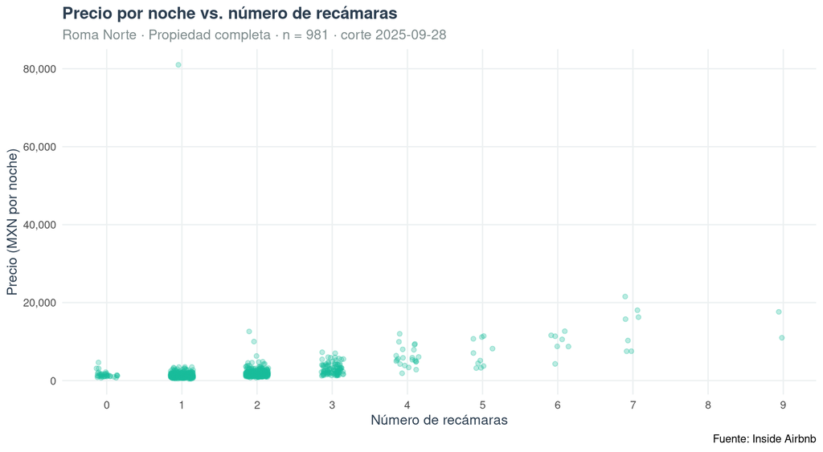

```r
ggplot(roma, aes(x = bedrooms, y = price)) +
  geom_jitter(width = 0.15, alpha = 0.3, color = colores$accent) +
  scale_y_continuous(labels = label_comma()) +
  scale_x_continuous(breaks = 0:9) +
  labs(
    title = "Precio por noche vs. número de recámaras",
    subtitle = paste0("Roma Norte · Propiedad completa · n = ",
                      nrow(roma), " · corte ", fecha_corte_iso),
    x = "Número de recámaras",
    y = "Precio (MXN por noche)",
    caption = "Fuente: Inside Airbnb"
  ) +
  theme_curso()
```

## 4. Construcción del modelo

### 4.1 Ajuste con `lm()`

```r
modelo <- lm(price ~ bedrooms, data = roma)
summary(modelo)
```

```
Call:
lm(formula = price ~ bedrooms, data = roma)

Residuals:
   Min     1Q Median     3Q    Max
 -3324   -850   -173    309  79800

Coefficients:
            Estimate Std. Error t value Pr(>|t|)
(Intercept)   -81.35     170.00  -0.479    0.632
bedrooms     1281.08      83.64  15.317   <2e-16 ***
---
Signif. codes:  0 '***' 0.001 '**' 0.01 '*' 0.05 '.' 0.1 ' ' 1

Residual standard error: 2872 on 979 degrees of freedom
Multiple R-squared:  0.1933,    Adjusted R-squared:  0.1925
F-statistic: 234.6 on 1 and 979 DF,  p-value: < 2.2e-16
```

### 4.2 Extracción de coeficientes

```r
coefs <- coef(modelo)
b0 <- coefs[["(Intercept)"]]
b1 <- coefs[["bedrooms"]]

cat("Ecuación estimada:\n")
```

```
Ecuación estimada:
```

```r
cat(sprintf("  precio = %.0f + %.0f × recámaras\n", b0, b1))
```

```
  precio = -81 + 1281 × recámaras
```

```r
cat("\nInterpretación:\n")
```

```
Interpretación:
```

```r
cat(sprintf("  β₀ = $%s → precio base estimado (0 recámaras)\n",
            format(round(b0), big.mark = ",")))
```

```
  β₀ = $-81 → precio base estimado (0 recámaras)
```

```r
cat(sprintf("  β₁ = $%s → incremento medio por cada recámara adicional\n",
            format(round(b1), big.mark = ",")))
```

```
  β₁ = $1,281 → incremento medio por cada recámara adicional
```

### 4.3 R² (referencia, no se discute formalmente en S4)

```r
r2 <- summary(modelo)$r.squared
cat(sprintf("R² = %.3f\n", r2))
```

```
R² = 0.193
```

```r
cat(sprintf("El modelo explica ~%.0f%% de la variación en precio.\n",
            100 * r2))
```

```
El modelo explica ~19% de la variación en precio.
```

```r
cat("(Esto se discutirá formalmente en S5.)\n")
```

```
(Esto se discutirá formalmente en S5.)
```

## 5. Interpretación de coeficientes

### 5.2 La pendiente (β₁)

β₁ ≈ $1,281 MXN. Por cada recámara adicional, el precio esperado por noche aumenta en ~$1,281.

**Advertencia**

**Esto es una asociación observada, no una relación causal.** No significa que “agregar una recámara” a un depto cause un aumento de $1,281. Puede ser que los deptos con más recámaras sean más grandes, mejor ubicados, o pertenezcan a hosts más profesionales — y sean *esas* características las que expliquen el precio más alto. La distinción correlación vs. causalidad se desarrolla a fondo en S6.

## 6. Predicción para Patricia

### 6.1 Predicción puntual

```r
pred_patricia <- predict(modelo, newdata = data.frame(bedrooms = 2))

cat(sprintf("Predicción para 2 recámaras: $%s MXN/noche\n",
            format(round(pred_patricia), big.mark = ",")))
```

```
Predicción para 2 recámaras: $2,481 MXN/noche
```

### 6.2 Comparación con referencias anteriores

```r
# Media y mediana del mercado completo (sin filtro de recámaras)
media_global   <- round(mean(roma$price), 0)
mediana_global <- round(median(roma$price), 0)

# Media del subgrupo de 2 recámaras
media_2rec <- round(mean(roma$price[roma$bedrooms == 2]), 0)

cat("Referencias previas (S1, todo Roma Norte Entire):\n")
```

```
Referencias previas (S1, todo Roma Norte Entire):
```

```r
cat(sprintf("  Media global  : $%s\n", format(media_global, big.mark = ",")))
```

```
  Media global  : $2,111
```

```r
cat(sprintf("  Mediana global: $%s\n", format(mediana_global, big.mark = ",")))
```

```
  Mediana global: $1,492
```

```r
cat(sprintf("\nMedia observada en 2 recámaras: $%s\n",
            format(media_2rec, big.mark = ",")))
```

```
Media observada en 2 recámaras: $1,880
```

```r
cat(sprintf("Predicción del modelo para 2 rec.: $%s\n",
            format(round(pred_patricia), big.mark = ",")))
```

```
Predicción del modelo para 2 rec.: $2,481
```

La predicción del modelo ($2,481) es más específica que la media global ($2,111), porque incorpora información sobre el número de recámaras. Esto ilustra el salto de “referencia genérica del mercado” a “estimación condicionada a las características de la propiedad”.

## 7. Visualización: recta sobre los datos

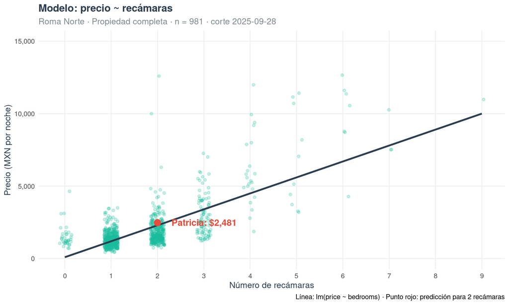

```r
ggplot(roma, aes(x = bedrooms, y = price)) +
  geom_jitter(width = 0.15, alpha = 0.25, color = colores$accent) +
  geom_smooth(method = "lm", formula = y ~ x, se = FALSE,
              color = colores$primary, linewidth = 1.2) +
  # Punto de predicción para Patricia
  annotate("point", x = 2, y = pred_patricia,
           color = colores$danger, size = 4) +
  annotate("text", x = 2.3, y = pred_patricia,
           label = paste0("Patricia: $",
                          format(round(pred_patricia), big.mark = ",")),
           color = colores$danger, hjust = 0, size = 4.5,
           fontface = "bold") +
  scale_y_continuous(labels = label_comma(), limits = c(0, 15000)) +
  scale_x_continuous(breaks = 0:9) +
  labs(
    title = "Modelo: precio ~ recámaras",
    subtitle = paste0("Roma Norte · Propiedad completa · n = ",
                      nrow(roma), " · corte ", fecha_corte_iso),
    x = "Número de recámaras",
    y = "Precio (MXN por noche)",
    caption = paste0("Línea: lm(price ~ bedrooms) · ",
                     "Punto rojo: predicción para 2 recámaras")
  ) +
  theme_curso()
```

## 8. Recomendación para Patricia

**Para: Patricia Domínguez** **Asunto: Primera estimación de precio basada en las características de tu propiedad**

En sesiones anteriores le proporcionamos referencias genéricas del mercado en Roma Norte (media y mediana). Hoy construimos un **modelo que relaciona el precio con el número de recámaras**, lo cual nos permite dar una estimación más específica.

**Resultado.** Ajustamos un modelo de regresión lineal simple sobre 981 propiedades completas en Roma Norte. La ecuación estimada es:

$$\text{precio} = -81 + 1,281 \times \text{recámaras}$$

Para su departamento de **2 recámaras**, la estimación es **$2,481 MXN por noche**. Este número es más informativo que la media del mercado ($2,111), porque toma en cuenta una característica concreta de su propiedad.

**Alcance y limitaciones.** Este es un primer modelo — solo usa una variable. No controla por otros factores que seguramente afectan el precio (amenidades, ubicación exacta, reseñas, capacidad). La precisión del modelo es limitada: hay mucha variación en precio entre propiedades con el mismo número de recámaras. La próxima sesión evaluará si el modelo es confiable y si sus supuestos se sostienen.

**Lo que este modelo NO responde aún.** Si la relación entre recámaras y precio es *causal*, cuánto margen de error tiene la estimación, ni si incluir más variables mejoraría sustancialmente la predicción. Todo eso se trabaja en las sesiones 5 a 7.

## 9. Preservación de resultados

La slide pública `slides/p3/04_regresion_simple_1.qmd` corre su propio `lm()` en vivo dentro de su setup chunk, así que los números del slide y los de este notebook deben coincidir exactamente. Si alguna vez no cuadran, es señal de que los pipelines divergieron.

```r
resultados_s04 <- list(
  # Muestra
  n_roma_entire    = nrow(roma),
  # Modelo
  intercepto       = round(b0, 0),
  pendiente        = round(b1, 0),
  r_cuadrada       = round(r2, 3),
  # Predicción Patricia
  pred_2rec        = round(pred_patricia, 0),
  # Descriptivos de referencia
  media_global     = media_global,
  mediana_global   = mediana_global,
  media_2rec       = media_2rec,
  # Contexto
  fecha_corte_iso  = fecha_corte_iso,
  fecha_corte_txt  = fecha_corte_txt
)

saveRDS(resultados_s04, "../datos/resultados_s04.rds")
message("Resultados guardados en datos/resultados_s04.rds")
```